# Analysis Stark Trek Commands

**TidyTuesday Project (210817)**

> - 📱 Linkedin [Juan Antonio Cabeza Sousa](https://www.linkedin.com/in/juan-antonio-cabeza-sousa-5b954968/)
> - 📬 Email: juaancabsou@gmail.com
> - 🖥️ Twitter: @Aceconhielo

This notebook is about *Analysing Star Trek Commands*.The data this week comes from [SpeechInteraction.org](http://www.speechinteraction.org/TNG/).

# A glance to the data

Looking the *Data Dictionary* related to this data set and the amount of missing values per column, it helps us to keep just a few important columns for the visualization stage. Those columns (the ones that I will kept for the TidyTuesday visualization) are: * `char`: Name of the speaking character. * `char_type`:Either Person or Computer * `line`: The complete line of dialog (may contain more speech than the speech interaction). Parenthetical are directions and not spoken. * `type`: The type of interaction, see detailed definitions below. * `pri_type`: The primary interaction type as defined by the below ranking. * `domain`: The domain of interaction, see detailed definitions below. * `sub_domain`: The sub-domain of interaction, generally a specific setting, see below. * `interaction`: The actual speech interaction. May be shorter or longer than the line of dialog.

I will discard `is_fed`and `error` because their distribution is always the same: TRUE and FALSE respectively.

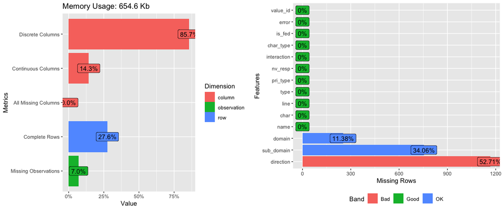

```r
ggarrange(chart_intro, chart_miss, ncol = 2, heights = c(10, 10))
```

```r
# Top 10 speakers: included computer voice
talkers <- head(
  computer %>%
  group_by(char) %>%
  count(sort = TRUE),10)$char

# Chart 1: Interactions
interactions <- head(computer %>% filter(char != 'Computer Voice') %>%
  group_by(char) %>%
  count(sort = TRUE),10)

interactions$char <- factor(interactions$char, levels = interactions$char[order(interactions$n)])
colnames(interactions) <- c('Character', 'Interactions')

# Chart 2: Wordclouds
textcleaned <- computer %>%
  unnest_tokens(word, interaction) %>%
  anti_join(get_stopwords(source = "snowball"))
df_wordcloud <- textcleaned %>% group_by(word) %>% count(sort = TRUE)

# Chart 3: Waffles
interactions_pct <- computer %>%
  filter(char %in% talkers) %>%
  group_by (char, type) %>%
  summarise (n=n()) %>%
  mutate(rel.freq = paste0(round(100 * n/sum(n), 0), "%"))
```

```r
backgroundcolor <- "#264653"
solidchartcolor <- "#e9c46a"
gridlines <- "#006d77"


# Chart 1: Interactions
chartinteractions<-
  ggplot(data=interactions, aes(x=Character, y=Interactions)) +
  geom_chicklet(stat="identity", color=solidchartcolor, fill=solidchartcolor, width = 0.75, radius = grid::unit(1, 'mm'))+
  geom_text(aes(label=Interactions), hjust=1.6,vjust= 0.5, color=backgroundcolor, size=3.5)+
  theme(
    axis.text.x = element_text(colour = 'white'),
    axis.title.x = element_text(colour = 'white'),
    axis.text.y = element_text(colour = 'white'),
    axis.title.y = element_text(colour = 'white'),
    panel.background = element_rect(fill = backgroundcolor, colour = backgroundcolor, linetype = "solid"),
    panel.grid.major = element_line(size = 0.5, linetype = 'solid', colour = gridlines),
    panel.grid.minor = element_line(size = 0.25, linetype = 'solid', colour = gridlines),
    plot.background = element_rect(fill = backgroundcolor),
    plot.title = element_text(colour="white"),
    plot.margin = unit(c(1,1,1,1), "cm")
  )+
  ggtitle("Users with more interactions")+
  coord_flip()
chartinteractions2<-
  ggplot() +
  theme(
    axis.text.x = element_text(colour = 'white'),
    axis.title.x = element_text(colour = 'white'),
    axis.text.y = element_text(colour = 'white'),
    axis.title.y = element_text(colour = 'white'),
    panel.background = element_rect(fill = backgroundcolor, colour = backgroundcolor, linetype = "solid"),
    panel.grid.major = element_line(size = 0.5, linetype = 'solid', colour = gridlines),
    panel.grid.minor = element_line(size = 0.25, linetype = 'solid', colour = gridlines),
    plot.background = element_rect(fill = backgroundcolor),
    plot.title = element_text(colour="white"),
    plot.margin = unit(c(1,1,1,1), "cm")
  )+
  coord_flip()
```

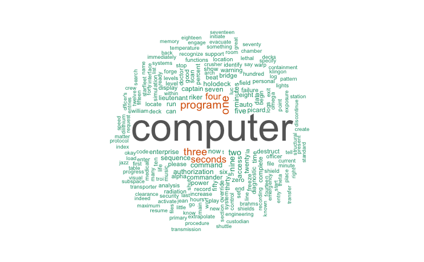

```r
wordcloudchart <- wordcloud(words = df_wordcloud$word ,
                            freq = df_wordcloud$n,
                            min.freq = 1,max.words=200,
                            random.order=FALSE,
                            rot.per=0.35,
                            colors=brewer.pal(8, "Dark2")
                            )
```

```r
library(waffle)

generatewaffle <- function(df,t,rows){
  wdata <- df %>% filter(char == t)
  wdata
  fig <- ggplot(wdata, aes(fill = type, values = n)) +
  geom_waffle(n_rows = rows, size = 0.33, colour = "white") +
  theme(
    axis.text.x = element_text(colour = 'white'),
    axis.title.x = element_blank(),
    axis.text.y = element_text(colour = 'white'),
    axis.title.y = element_blank(),
    panel.background = element_rect(fill = backgroundcolor, colour = backgroundcolor, linetype = "solid"),
    panel.grid.major = element_line(size = 0.5, linetype = 'solid', colour = backgroundcolor),
    panel.grid.minor = element_line(size = 0.25, linetype = 'solid', colour = backgroundcolor),
    plot.background = element_rect(fill = backgroundcolor),
    plot.title = element_text(colour="white"),
    legend.background = element_rect(colour = "transparent", fill = backgroundcolor),
    legend.title = element_text(color = backgroundcolor),
    legend.text = element_text(color = "white"),
    legend.key = element_rect(fill = backgroundcolor, color = NA),
  )+
  ggtitle(paste0(t,": Types of interaction"))

  return(fig)
}

fig1 <- generatewaffle(interactions_pct, "Computer Voice", 20)
fig2 <- generatewaffle(interactions_pct, "Geordi", 20)
fig3 <- generatewaffle(interactions_pct, "Picard", 20)
fig4 <- generatewaffle(interactions_pct, "Data",10)
fig5 <- generatewaffle(interactions_pct, "Riker", 10)
fig6 <- generatewaffle(interactions_pct, "Beverly", 10)
```

[output not shown]

[figure not shown]

```r
library(ggpubr)
ggarrange(
  ggarrange(chartinteractions,fig1, ncol=2),
  ggarrange(fig2, fig3, ncol=2),
  ggarrange(fig4, fig5, fig6, ncol=3),
  nrow=3,
  solidchartcolor='red'
)
```